# Biostat 203B Homework 4

Due Mar 18 @ 11:59PM

Yenlin Lai

Load database libraries and the tidyverse frontend:

```r
suppressPackageStartupMessages(library(tidyverse))
suppressPackageStartupMessages(library(lubridate))
suppressPackageStartupMessages(library(miceRanger))
```

## Q1. Missing data

Through the Shiny app developed in HW3, we observe abundant missing values in the MIMIC-IV ICU cohort we created. In this question, we use multiple imputation to obtain a data set without missing values.

0. Read following tutorials on the R package miceRanger for imputation: https://github.com/farrellday/miceRanger, https://cran.r-project.org/web/packages/miceRanger/vignettes/miceAlgorithm.html.

   A more thorough book treatment of the practical imputation strategies is the book [*Flexible Imputation of Missing Data*](https://stefvanbuuren.name/fimd/) by Stef van Buuren.
1. Explain the jargon MCAR, MAR, and MNAR.  
   **Solution:**  
   MCAR: Missing completely at random. The missing values are not systematically different from the values we did observe, meaning that causes of the missing data are unrelated to the data.  
   MAR: Missing at random. The missing values are systematically different from the observed values, but the systematic differences are fully accounted for by measured covariates. MAR is more general and more realistic than MCAR. Modern missing data methods generally start from the MAR assumption.  
   MNAR: Missing not at random. The probability of being missing varies for reasons that are unknown to us, meaning that the missing values are thought to systematically differ from observed values.
2. Explain in a couple of sentences how the Multiple Imputation by Chained Equations (MICE) work.  
   **Solution:** MICE is a multiple imputation method used to replace missing data values in a data set under certain assumptions about the data missingness mechanism (e.g., the data are missing at random, the data are missing completely at random). MICE works as following phases:
- Imputation or Fill-in Phase: The missing data are filled in with estimated values and a complete data set is created. This process of fill-in is repeated m times.
- Analysis Phase: Each of the m complete data sets is then analyzed using a statistical method of interest (e.g. linear regression).
- Pooling Phase: The parameter estimates (e.g. coefficients and standard errors) obtained from each analyzed data set are then combined for inference. This process is continued until all specified variables have been imputed. Additional iterations can be run if it appears that the average imputed values have not converged, although no more than 5 iterations are usually necessary.
3. Perform a data quality check of the ICU stays data. Discard variables with substantial missingness, say >5000 `NA`s. Replace apparent data entry errors by `NA`s.  
   **Solution:**

```r
icu_cohort <- readRDS("icu_cohort.rds")

#decide which variables have more than 5000 NAs
na_count <- icu_cohort %>%
  sapply(function(y) sum(is.na(y)))
na_count %>%
  data.frame() %>%
  filter(. > 5000)
```

```
##                                          .
## deathtime                            47558
## edregtime                            19613
## edouttime                            19613
## dod                                  45148
## magnesium                            13128
## potassium                            10267
## sodium                               10336
## white_blood_cell_count                6423
## bicarbonate                          10519
## calcium                              13669
## chloride                             10058
## creatinine                           10303
## glucose                              11696
## body_temperature_in_Fahrenheit       41444
## systolic_non_invasive_blood_pressure 38114
## mean_non_invasive_blood_pressure     38055
## respiratory_rate                     17409
## heart_rate                           14354
```

```r
#create a data without variables with substantial missingness
icu_cohort_na <-
  icu_cohort %>%
  select(-c(deathtime, edregtime, edouttime, dod, magnesium, potassium,
            sodium, white_blood_cell_count, bicarbonate, calcium, chloride,
            creatinine, glucose, body_temperature_in_Fahrenheit,
            systolic_non_invasive_blood_pressure,
            mean_non_invasive_blood_pressure, respiratory_rate, heart_rate))

#define outliers
#there is only one continuous variable with NAs
outliers <- boxplot(icu_cohort_na$hematocrit, plot = FALSE)$out

#replace apparent data entry errors by NAs
icu_cohort_na[icu_cohort_na$hematocrit %in% outliers, "hematocrit"] = NA

print(icu_cohort_na, width = Inf)
```

```
## # A tibble: 53,065 × 25
##    subject_id intime               hadm_id  stay_id first_careunit
##         <int> <dttm>                 <int>    <int> <chr>
##  1   12776735 2200-07-12 00:33:00 20817525 34547665 Neuro Stepdown
##  2   16256226 2150-12-20 16:09:08 20013290 39289362 Neuro Stepdown
##  3   12974563 2138-11-13 23:30:01 29618057 32563675 Neuro Stepdown
##  4   14609218 2174-06-28 21:13:00 20606189 34947848 Neuro Stepdown
##  5   12687112 2162-05-31 18:08:45 26132667 37445058 Neuro Stepdown
##  6   18190935 2115-11-12 23:23:32 21137829 34338402 Neuro Stepdown
##  7   10404210 2161-03-03 18:30:00 22880512 30254828 Neuro Stepdown
##  8   12552973 2135-09-21 18:12:03 21320643 30261549 Neuro Stepdown
##  9   14303051 2175-11-20 01:02:00 26559537 30401486 Neuro Stepdown
## 10   12347959 2140-07-11 17:54:14 22779073 30503984 Neuro Stepdown
##    last_careunit  outtime               los admittime
##    <chr>          <dttm>              <dbl> <dttm>
```

[output cut: 59 more lines]

```r
na_count_na <- icu_cohort_na %>%
  sapply(function(y) sum(is.na(y)))
na_count_na
```

```
##           subject_id               intime              hadm_id
##                    0                    0                    0
##              stay_id       first_careunit        last_careunit
##                    0                    0                    0
##              outtime                  los            admittime
##                    0                    0                    0
##            dischtime       admission_type   admission_location
##                    0                    0                    0
##   discharge_location            insurance             language
##                  492                    0                    0
##       marital_status            ethnicity hospital_expire_flag
##                 4617                    0                    0
##               gender           anchor_age          anchor_year
##                    0                    0                    0
##    anchor_year_group        age_admission           hematocrit
##                    0                    0                 5106
##      thirty_day_mort
##                    0
```

4. Impute missing values by `miceRanger` (request $m=3$ data sets). This step is computational intensive. Make sure to save the imputation results as a file. Hint: Setting `max.depth=10` in the `miceRanger` function may cut some computing time.  
   **Solution:**

```r
icu_impute <-
  miceRanger(icu_cohort_na,
             m = 3,
             max.depth=10)
```

```
## One or more of the specified variables to impute contains no missing values. These will remain as a predictor, however they will not be imputed.
```

```
## Converting characters to factors.
```

```
##
## Process started at 2022-03-14 23:44:14
```

[output not shown]

5. Make imputation diagnostic plots and explain what they mean.  
   **Solution:**
- Distribution of Imputed Values: The red line is the density of the original, non-missing data. The smaller, black lines are the density of the imputed values in each of the datasets. If these don’t match up, it’s not a problem, however it may tell you that your data was not Missing Completely at Random (MCAR).

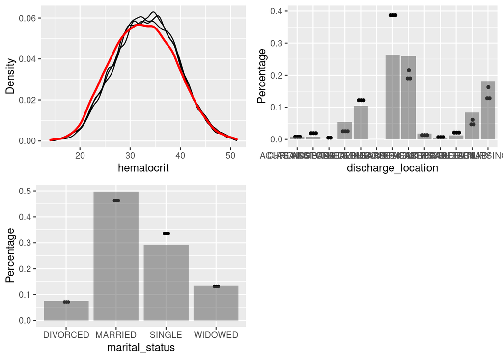

```r
plotDistributions(icu_impute)
```

- Convergence of Correlation: It shows a boxplot of the correlations between imputed values in every combination of datasets, at each iteration.

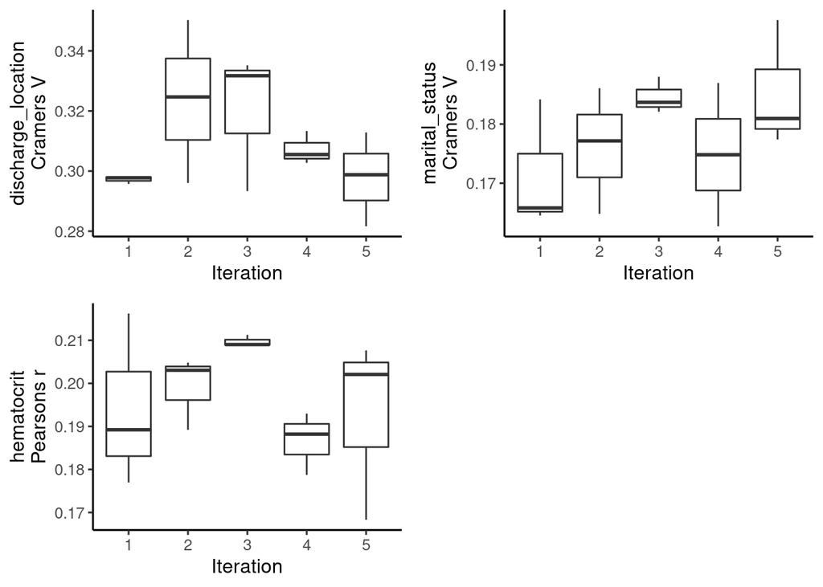

```r
plotCorrelations(icu_impute)
```

- Center and Dispersion Convergence: Sometimes, if the missing data locations are correlated with higher or lower values, we need to run multiple iterations for the process to converge to the true theoretical mean (given the information that exists in the dataset). We can see if the imputed data converged, or if we need to run more iterations. It doesn’t look like this dataset had a convergence issue. When plotting categorical variables, the center and dispersion metrics plotted are the percent of the mode and the entropy, respectively.

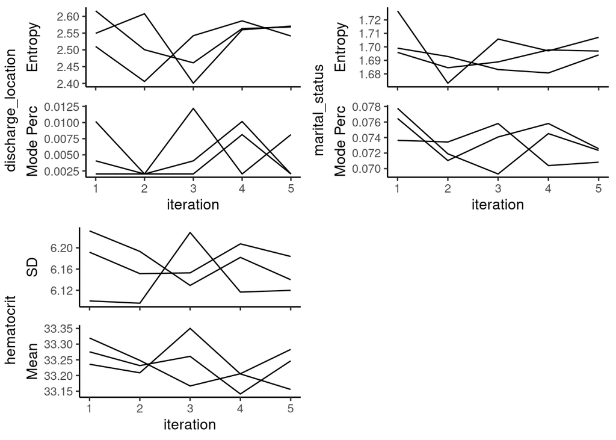

```r
plotVarConvergence(icu_impute)
```

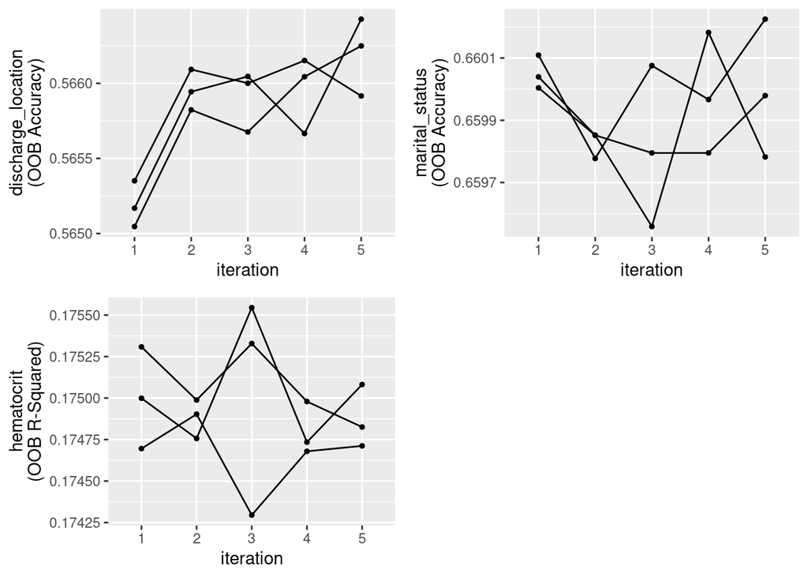

```r
plotModelError(icu_impute)
```

6. Choose one of the imputed data sets to be used in Q2. This is **not** a good idea to use just one imputed data set or to average multiple imputed data sets. Explain in a couple of sentences what the correct Multiple Imputation strategy is.  
   **Solution:**

```r
icu_impute_2 <- completeData(icu_impute)[[2]]
```

We choose the second imputed data set to be used in Q2. We would like to use 3 to 10 imputed data sets and fit the model to each of the multiple imputations and then combine the results (e.g. using Rubin’s Rules) when we are doing Multiple Imputation. Rubin’s Rules are designed to pool parameter estimates, such as mean differences, regression coefficients, standard errors and to derive confidence intervals and p-values. Combining the results using Rubin’s Rules can lower the random error effect. Rubin’s Rules can be approached using `pool` in R.

## Q2. Predicting 30-day mortality

Develop at least two analytic approaches for predicting the 30-day mortality of patients admitted to ICU using demographic information (gender, age, marital status, ethnicity), first lab measurements during ICU stay, and first vital measurements during ICU stay. For example, you can use (1) logistic regression (`glm()` function in base R or keras), (2) logistic regression with lasso penalty (glmnet or keras package), (3) random forest (randomForest package), or (4) neural network (keras package).

1. Partition data into 80% training set and 20% test set. Stratify partitioning according the 30-day mortality status.  
   **Solution:**

```r
library(splitTools)
set.seed(203)
icu_impute_2$thirty_day_mort <-
  ifelse(icu_impute_2$thirty_day_mort == "Yes" ,1 , 0)
icu_impute_2 <- transform(icu_impute_2,
                          gender = as.factor(gender),
                          marital_status = as.factor(marital_status),
                          ethnicity = as.factor(ethnicity),
                          thirty_day_mort = as.factor(thirty_day_mort))
sets <- partition(icu_impute_2$thirty_day_mort, p = c(train = 0.8, test = 0.2))

icu_train <- icu_impute_2[sets$train, ]
icu_test <- icu_impute_2[sets$test, ]
```

2. Train the models using the training set.  
   **Solution:**  
   We use logistic regression and random forest to predict the 30-day mortality of patients admitted to ICU.
- Logistic regression

```r
logistic <- glm(thirty_day_mort ~
                  gender + anchor_age + marital_status + ethnicity + hematocrit
                  , family=binomial(link='logit'), data=icu_train)
summary(logistic)
```

```
##
## Call:
## glm(formula = thirty_day_mort ~ gender + anchor_age + marital_status +
##     ethnicity + hematocrit, family = binomial(link = "logit"),
##     data = icu_train)
##
## Deviance Residuals:
##     Min       1Q   Median       3Q      Max
## -1.0061  -0.5029  -0.4104  -0.3276   2.7647
##
## Coefficients:
##                                  Estimate Std. Error z value Pr(>|z|)
## (Intercept)                     -4.236953   0.451296  -9.388   <2e-16 ***
## genderM                         -0.001271   0.034451  -0.037   0.9706
## anchor_age                       0.030796   0.001210  25.457   <2e-16 ***
## marital_statusMARRIED           -0.048712   0.065671  -0.742   0.4582
## marital_statusSINGLE             0.164072   0.069296   2.368   0.0179 *
## marital_statusWIDOWED            0.064472   0.073784   0.874   0.3822
## ethnicityASIAN                   0.296828   0.441734   0.672   0.5016
## ethnicityBLACK/AFRICAN AMERICAN -0.053268   0.436043  -0.122   0.9028
## ethnicityHISPANIC/LATINO        -0.028569   0.443827  -0.064   0.9487
## ethnicityOTHER                   0.014920   0.439362   0.034   0.9729
## ethnicityUNABLE TO OBTAIN        0.673678   0.446556   1.509   0.1314
## ethnicityUNKNOWN                 0.947129   0.433614   2.184   0.0289 *
## ethnicityWHITE                  -0.050842   0.432441  -0.118   0.9064
## hematocrit                      -0.004377   0.002614  -1.674   0.0941 .
## ---
## Signif. codes:  0 '***' 0.001 '**' 0.01 '*' 0.05 '.' 0.1 ' ' 1
##
## (Dispersion parameter for binomial family taken to be 1)
##
##     Null deviance: 28050  on 42451  degrees of freedom
## Residual deviance: 26690  on 42438  degrees of freedom
## AIC: 26718
##
## Number of Fisher Scoring iterations: 5
```

- Random forest

```r
library(randomForest)
rf <- randomForest(thirty_day_mort ~
                  gender + anchor_age + marital_status + ethnicity + hematocrit
                  , data=icu_train)
```

3. Compare model prediction performance on the test set.  
   **Solution:**
- Logistic regression

```r
lr_probab <- predict(logistic, icu_test, type='response')
lr_pred <- ifelse(lr_probab > 0.5, 1, 0)
library(caret)
confusionMatrix(factor(lr_pred), factor(icu_test$thirty_day_mort))
```

```
## Confusion Matrix and Statistics
##
##           Reference
## Prediction    0    1
##          0 9526 1087
##          1    0    0
##
##                Accuracy : 0.8976
##                  95% CI : (0.8917, 0.9033)
##     No Information Rate : 0.8976
##     P-Value [Acc > NIR] : 0.5081
##
##                   Kappa : 0
##
##  Mcnemar's Test P-Value : <2e-16
##
##             Sensitivity : 1.0000
##             Specificity : 0.0000
##          Pos Pred Value : 0.8976
##          Neg Pred Value :    NaN
##              Prevalence : 0.8976
##          Detection Rate : 0.8976
##    Detection Prevalence : 1.0000
##       Balanced Accuracy : 0.5000
##
##        'Positive' Class : 0
##
```

- Random forest

```r
rf_pred <- predict(rf, icu_test)
confusionMatrix(rf_pred, icu_test$thirty_day_mort)
```

```
## Confusion Matrix and Statistics
##
##           Reference
## Prediction    0    1
##          0 9514 1083
##          1   12    4
##
##                Accuracy : 0.8968
##                  95% CI : (0.8909, 0.9025)
##     No Information Rate : 0.8976
##     P-Value [Acc > NIR] : 0.6087
##
##                   Kappa : 0.0043
##
##  Mcnemar's Test P-Value : <2e-16
##
##             Sensitivity : 0.99874
##             Specificity : 0.00368
##          Pos Pred Value : 0.89780
##          Neg Pred Value : 0.25000
##              Prevalence : 0.89758
##          Detection Rate : 0.89645
##    Detection Prevalence : 0.99849
##       Balanced Accuracy : 0.50121
##
##        'Positive' Class : 0
##
```